# Paper Example 2: MCAR missingness and custom criterion callbacks

This vignette reproduces the MCAR missingness component of Schroeders and Gnambs (2025) Example 2 as far as irtsim’s current API permits. The paper’s full Example 2 uses a bivariate latent trait (theta + external criterion) with a TAM latent regression — features irtsim does not yet support. What we *can* reproduce is the impact of MCAR missingness on item parameter recovery, which is one of the paper’s key design variables.

We also demonstrate irtsim’s **custom criterion callback** (`criterion_fn`), which lets users compute arbitrary item-level metrics on top of the built-in bias/MSE/RMSE/coverage.

## Background

A researcher is developing a 30-item personality scale administered online. Due to respondent burden, some participants see only a random subset of items (MCAR at 30%). We compare complete data (0% missing) to 30% MCAR, asking: **how much does MCAR missingness degrade item parameter recovery, and how large a sample is needed to compensate?**

## Study Design

```r
library(irtsim)

set.seed(2024)
n_items <- 30

params <- irt_params_2pl(
  n_items = n_items,
  a_dist  = "lnorm",
  a_mean  = 0.2,
  a_sd    = 0.3,
  b_mean  = 0,
  b_sd    = 1,
  seed    = 2024
)

design <- irt_design(
  model       = "2PL",
  n_items     = n_items,
  item_params = params,
  theta_dist  = "normal"
)

sample_sizes <- seq(200, 1000, by = 200)

study_complete <- irt_study(design, sample_sizes = sample_sizes)

study_mcar30 <- irt_study(
  design,
  sample_sizes = sample_sizes,
  missing      = "mcar",
  missing_rate = 0.30
)

res_complete <- irt_simulate(study_complete, iterations = 500,
                             seed = 2024, parallel = TRUE)
res_mcar30   <- irt_simulate(study_mcar30,   iterations = 500,
                             seed = 2024, parallel = TRUE)
```

> **Note on reproducibility.** Precomputed with `parallel = TRUE`. See `?irt_simulate` for the serial/parallel reproducibility contract.

## Proportion of Items Meeting RMSE Threshold

At each sample size, what fraction of items achieve acceptable RMSE? This captures the full story: both items that converge quickly and items that never converge, which a single `max(recommended_n)` would hide.

```r
#' Compute proportion of items meeting a criterion threshold at each N
prop_meeting <- function(res, criterion, threshold, param = NULL) {
  s <- summary(res, criterion = criterion, param = param)
  df <- s$item_summary
  cfg <- irtsim:::get_criterion_config(criterion)
  vals <- df[[criterion]]
  if (cfg$use_abs) vals <- abs(vals)
  if (cfg$direction == "higher_is_better") {
    df$meets <- !is.na(vals) & vals >= threshold
  } else {
    df$meets <- !is.na(vals) & vals <= threshold
  }
  agg <- aggregate(meets ~ sample_size, data = df,
                   FUN = function(x) mean(x))
  names(agg)[2] <- "prop_meeting"
  agg
}
```

### Discrimination (a)

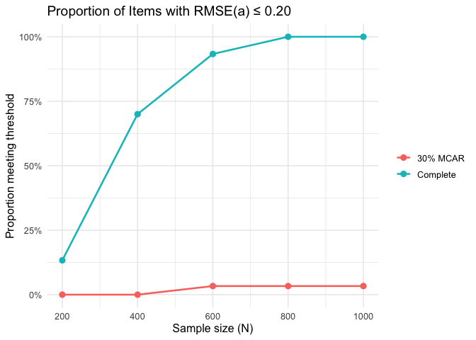

```r
prop_a_complete <- prop_meeting(res_complete, "rmse", 0.20, param = "a")
prop_a_complete$condition <- "Complete"

prop_a_mcar <- prop_meeting(res_mcar30, "rmse", 0.20, param = "a")
prop_a_mcar$condition <- "30% MCAR"

prop_a <- rbind(prop_a_complete, prop_a_mcar)

ggplot(prop_a, aes(x = sample_size, y = prop_meeting, colour = condition)) +
  geom_line(linewidth = 0.9) +
  geom_point(size = 2.5) +
  scale_y_continuous(labels = scales::percent_format(), limits = c(0, 1)) +
  labs(
    title = "Proportion of Items with RMSE(a) \u2264 0.20",
    x = "Sample size (N)", y = "Proportion meeting threshold",
    colour = NULL
  ) +
  theme_minimal(base_size = 12)
```

### Difficulty (b)

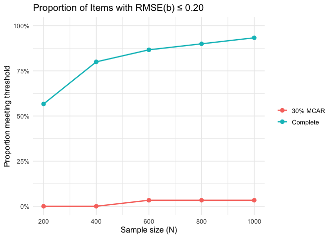

```r
prop_b_complete <- prop_meeting(res_complete, "rmse", 0.20, param = "b")
prop_b_complete$condition <- "Complete"

prop_b_mcar <- prop_meeting(res_mcar30, "rmse", 0.20, param = "b")
prop_b_mcar$condition <- "30% MCAR"

prop_b <- rbind(prop_b_complete, prop_b_mcar)

ggplot(prop_b, aes(x = sample_size, y = prop_meeting, colour = condition)) +
  geom_line(linewidth = 0.9) +
  geom_point(size = 2.5) +
  scale_y_continuous(labels = scales::percent_format(), limits = c(0, 1)) +
  labs(
    title = "Proportion of Items with RMSE(b) \u2264 0.20",
    x = "Sample size (N)", y = "Proportion meeting threshold",
    colour = NULL
  ) +
  theme_minimal(base_size = 12)
```

## Aggregate RMSE Trajectories

The ribbon shows the range (min to max) across items; the line is the mean.

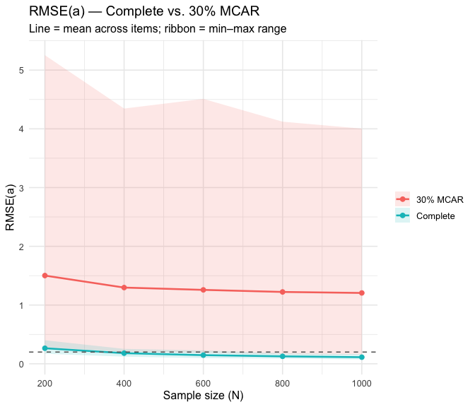

```r
make_agg <- function(res, param, label) {
  s <- summary(res, criterion = "rmse", param = param)
  agg <- aggregate(
    rmse ~ sample_size,
    data = s$item_summary,
    FUN = function(x) c(mean = mean(x), min = min(x), max = max(x))
  )
  agg <- do.call(data.frame, agg)
  names(agg) <- c("sample_size", "mean_rmse", "min_rmse", "max_rmse")
  agg$condition <- label
  agg
}

agg_all <- rbind(
  make_agg(res_complete, "a", "Complete"),
  make_agg(res_mcar30,   "a", "30% MCAR")
)

ggplot(agg_all, aes(x = sample_size, colour = condition, fill = condition)) +
  geom_ribbon(aes(ymin = min_rmse, ymax = max_rmse), alpha = 0.15, colour = NA) +
  geom_line(aes(y = mean_rmse), linewidth = 0.9) +
  geom_point(aes(y = mean_rmse), size = 2) +
  geom_hline(yintercept = 0.20, linetype = "dashed", colour = "grey40") +
  labs(
    title    = "RMSE(a) \u2014 Complete vs. 30% MCAR",
    subtitle = "Line = mean across items; ribbon = min\u2013max range",
    x = "Sample size (N)", y = "RMSE(a)", colour = NULL, fill = NULL
  ) +
  theme_minimal(base_size = 12)
```

## Custom Criterion: Standard Error of Measurement

irtsim’s `criterion_fn` argument to `summary()` lets users define arbitrary item-level criteria. Here we compute the average standard error across replications, derived from the CI width.

```r
sem_at_theta <- function(estimates, true_value, ci_lower, ci_upper, converged, ...) {
  valid <- !is.na(ci_lower) & !is.na(ci_upper)
  if (!any(valid)) return(c(sem = NA))
  se_vec <- (ci_upper[valid] - ci_lower[valid]) / 3.92
  c(sem = mean(se_vec, na.rm = TRUE))
}

sum_complete_custom <- summary(res_complete, criterion_fn = sem_at_theta)
sum_mcar30_custom   <- summary(res_mcar30,   criterion_fn = sem_at_theta)
```

Any function with the signature `f(estimates, true_value, ci_lower, ci_upper, converged, ...) -> named numeric` can be passed to `summary()`. This lets users compute domain-specific metrics without modifying irtsim internals.

## Theta Recovery

```r
sum_complete <- summary(res_complete)
sum_mcar30   <- summary(res_mcar30)

cat("=== Theta Recovery ===\n\n")
```

```
#> === Theta Recovery ===
```

```r
cat("Complete data:\n")
```

```
#> Complete data:
```

```r
print(sum_complete$theta_summary[, c("sample_size", "mean_cor", "mean_rmse")])
```

```
#>   sample_size  mean_cor mean_rmse
#> 1         200 0.9349194 0.3604117
#> 2         400 0.9364936 0.3549195
#> 3         600 0.9366280 0.3535303
#> 4         800 0.9366737 0.3521547
#> 5        1000 0.9369620 0.3511869
```

```r
cat("\n30% MCAR:\n")
```

```
#>
#> 30% MCAR:
```

```r
print(sum_mcar30$theta_summary[, c("sample_size", "mean_cor", "mean_rmse")])
```

```
#>   sample_size  mean_cor mean_rmse
#> 1         200 0.9382237 0.3522167
#> 2         400 0.9387197 0.3481326
#> 3         600 0.9390215 0.3463960
#> 4         800 0.9388606 0.3465829
#> 5        1000 0.9392179 0.3448338
```

## Summary

```r
rec_a_complete <- recommended_n(sum_complete, criterion = "rmse",
                                threshold = 0.20, param = "a",
                                aggregate = "none")
rec_a_mcar     <- recommended_n(sum_mcar30,   criterion = "rmse",
                                threshold = 0.20, param = "a",
                                aggregate = "none")

n_items <- nrow(rec_a_complete)
n_na_complete <- sum(is.na(rec_a_complete$recommended_n))
n_na_mcar     <- sum(is.na(rec_a_mcar$recommended_n))

cat("Items tested:", n_items, "\n")
```

```
#> Items tested: 30
```

```r
cat("Items reaching RMSE(a) <= 0.20:\n")
```

```
#> Items reaching RMSE(a) <= 0.20:
```

```r
cat("  Complete:", n_items - n_na_complete, "of", n_items, "\n")
```

```
#>   Complete: 30 of 30
```

```r
cat("  30% MCAR:", n_items - n_na_mcar, "of", n_items, "\n")
```

```
#>   30% MCAR: 1 of 30
```

MCAR missingness reduces the effective information per item per person, which increases RMSE and inflates sample-size requirements. The proportion-meeting-threshold plots show this at each N: fewer items achieve acceptable precision under MCAR than under complete data. The magnitude of the penalty depends on the missingness rate, the number of items, and the discrimination structure.

The `criterion_fn` callback demonstrated here allows users to define domain-specific metrics without modifying irtsim internals.

## References

Morris, T. P., White, I. R., & Crowther, M. J. (2019). Using simulation studies to evaluate statistical methods. *Statistics in Medicine*, 38(11), 2074–2102.

Schroeders, U., & Gnambs, T. (2025). Sample-size planning in item response theory: A tutorial. *Advances in Methods and Practices in Psychological Science*, 8(1).